# BF528 Final Report

Johnathan Zhang

2024-05-01

# BF528 Final Project ATACSeq Pipeline

## Introduction

ATAC-Seq is often used to assay regions of the genome that have open chromatin, operating under the assumption that open chromatin is related to the regulation of gene expression. The protocol takes advantage of Tn5 Transposase and it’s ability to readily splice nucleosome-free (or any protein-free) DNA. These segments of DNA can be of varying length and patterns can be observed corresponding to the amount of DNA typically wrapped around a nucleosome. These segments are sequenced and computationally, ATAC-Seq operates very similarly to ChIP-Seq. The raw reads are highly enriched at specific regions of the genome, specifically where chromatin is open, and these regions are turned into “peaks”. / In this project, we perform a number of ATAC-Seq analyses on data found from [this article](https://www.nature.com/articles/nmeth.2688) using a number of different software. The software and data are all linked together through a snakemake pipeline.

## Methods

### Raw Sequence Processing

Raw sequencing reads for the study’s two ATAC-Seq replicates (rep3, rep4) can be obtained from GEO accession GSE47753. To perform quality assessment of raw sequencing reads, [FastQC 0.12.1](https://www.bioinformatics.babraham.ac.uk/projects/fastqc/) was used to inspect a number of quality metrics for each fastq file. [Trimmomatic 0.39](http://www.usadellab.org/cms/?page=trimmomatic) was used in paired-end mode to quality filter and remove remaining adapter sequence (NexteraPE-PE.fasta) from raw sequencing files. Custom Trimmomatic flags included `LEADING:3, TRAILING:3, SLIDINGWINDOW:4:15, ILLUMINACLILP:2:30:10`. Unpaired reads were discarded.

To perform read mapping, human genome reference GRChg38 was first indexed using [Bowtie 2.5.3](https://bowtie-bio.sourceforge.net/bowtie2/index.shtml) `build` with default parameters. Using the index, post-trimmomatic sequencing reads were aligned to the reference using Bowtie2 and the `-X 2000` flag to increase max fragment length and enhance signal capture. [Samtools 1.19.2](https://www.htslib.org/) `flagstat` generated a report on each replicate alignment’s quality, and these reports were combined with the FastQC reports with [MultiQC 1.20](https://multiqc.info/) to generate a concatenated quality assessment report. Alignment files were sorted using Samtools `sort` and indexed using Samtools `index`. Reads that mapped to mitochondrial genome were removed for downstream analyses.

### Peak Calling and Motif Analysis

To deal with tagmentation, [Deeptools 3.5.4](https://deeptools.readthedocs.io/en/develop/) `alignmentSieve` was used with flags `--ATACshift` to filter alignments and shift them corresponding to the 9-bp duplication created by Tn5 transposase. To perform quality control and generate a plot on fragment distribution sizes, Bioconductor package [ATACSeqQC 1.28.0](https://www.bioconductor.org/packages/release/bioc/html/ATACseqQC.html) in a custom R script [R 4.3.1](https://www.r-project.org/) was used on the bams containing all fragment sizes. Peak calling was performed using [MACS3](https://github.com/macs3-project/MACS) with default parameters for each replicate. [BedTools 2.31.1](https://bedtools.readthedocs.io/en/latest/) `intersect` with flags `-r (0.5)` was used to generate a list of reproducible peaks, and to remove blacklisted regions. [HOMER 4.11](http://homer.ucsd.edu/homer/) `annotatePeaks` was used to annotate peaks with Gencode’s v45 human reference annotation file (gtf), and `findMotifsGenome` was used to perform motif analysis..

### Signal Coverage

To generate signal coverage plots of nucleosome free regions (NFR) and nucleosome bound regions (mono-nucleosomes, di-nucleosome), Deeptools `alignmentSieve` was also run with flags `--minFragmentLenght` and `--maxFragmentLength` with varying values. For NFR, the maximum length was set to 100. For mononucleosomes, the basepair range of fragments was [180,247]. For dinucleosomes, the basepair range of fragments was [315,473]. All produced bams were re-sorted and re-indexed using Samtools. Each pair of bams (replicate 3, replicate 4) was combined using Deeptools `bamCompare` with flags `--operation mean --normalizeUsing RPKM --scaleFactorsMethod None -bs 10`. This specifies the bams to be normalized by RPKM to account for differences in sequencing depth and to take the average signal for a bin size of 10. After merging bams, Deeptools `computeMatrix reference-point` was used to generate a signal coverage matrix of gene regions (hg38 downloaded from UCSC refseq table browser). Regions 1000 basepairs up and down stream of the center point were analyzed using the `-a` and `-b` flags. The matrix was used to generate a signal coverage plot using Deeptools `plot_profile`.

### Gene Enrichment

Gene enrichment analysis on annotated peaks was performed using [DAVID Functional annotation](https://david.ncifcrf.gov/). A list of gene names was extracted from the annotate peaks files and uploaded to DAVID’s functional annotation web browser.

### Proportion of regions pie chart

R was used to generate the figure for deliverable #8 following [this](https://codingenes.wordpress.com/2012/04/25/making-pie-graph-annotations-from-homer-output/) online blog.

## Results/Deliverables

For the ATAC-Seq project, there were 8 deliverables, labeled #1-#8.

### 0: Quality control and analysis

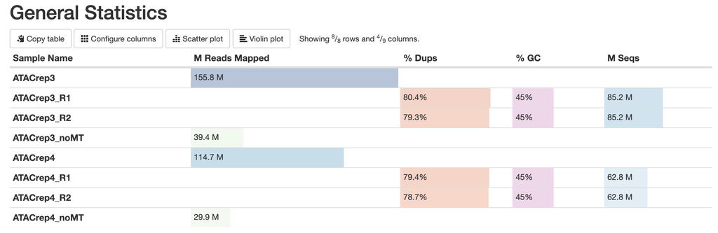

```r
knitr::include_graphics("general_statistics.png")
```

These general statistics tell a lot about the two replicates we used from the original study. After alignment, the number of reads appears satisfactory for coverage across the whole genome at 100+M (ATACrep{3,4}). However, characteristic of ATAC-Seq, we see a high percentage of duplicate reads in the original raw read file paris (ATACrep{3,4}_R{1,2}). This can also be seen with FastQC’s duplication level figure, shown below. We know that Tn5 Transposase will cleave any nucleosome free DNA, and consequently mitochondrial DNA will be highly representated in the reads. Filtering out reads that mapped to the mitochondrial genome reduced the size of our library by a significant amount, to roughly 30-40 M reads (ATACrep{3,4}_noMT).

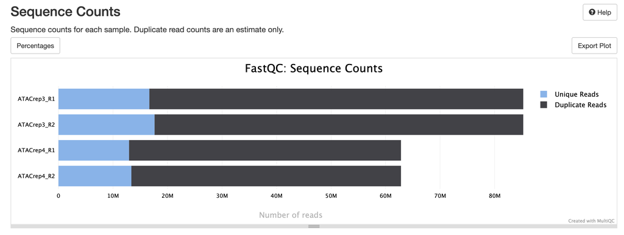

```r
knitr::include_graphics("sequence_counts.png")
```

### 1: Fragment length distribution plots

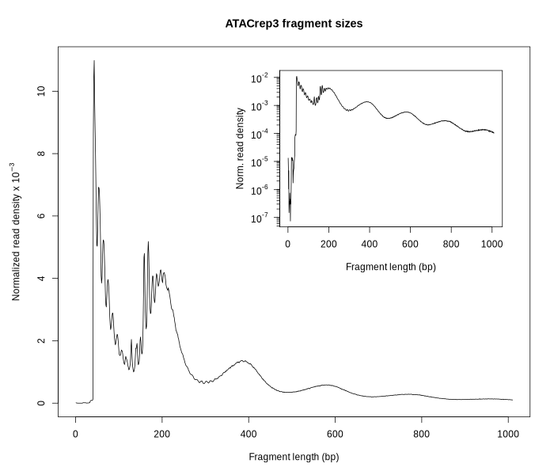

```r
knitr::include_graphics("ATACrep3_frag_size_dist.png")
```

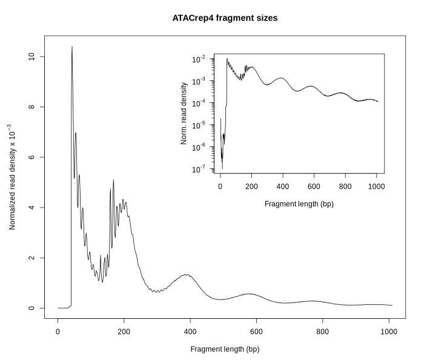

```r
knitr::include_graphics("ATACrep4_frag_size_dist.png")
```

These plots show a distribution of fragment lengths collected from sequencing. There are clear bumps displaying the nucleosome free regions (<150 bp), mono-nucleosome bound regions (b/w 150-300bp), di-nucleosome bound regions (300-480bp), etc. High similarity is observed across both replicates as well. Plots were produced using a custom R script employing ATACSeqQC.

### 2. Filtering mitochondrial genome reads

**Table 1** Table showing number of reads in each replicate mapping to the Mitochondrial Genome

| Replicate | Number of Mapped Reads | Number of Mapped Reads no MT | Number of MT Reads |
| --- | --- | --- | --- |
| Rep3 | 155,771,633 | 39,439,668 | 116,331,965 |
| Rep4 | 114,717,279 | 29,879,878 | 84,837,401 |

Part of standard ATAC-Seq protocol is to filter out reads that have mapped to the mitochondrial genome. This is particularly important in ATAC-Seq given the principle of Tn5 Transposase preferentially binding to nucleosome-free DNA (e.g. mitochondrial DNA). After using bowtie2 to align our paired end reads to hg38 reference genome, we use Samtools and awk to remove alignments that align to ‘chrM’. Flagstats is used to assess the number of reads present in the pre/post-filtered bams, and the results are presented in the table above. Expectedly, a large proportion of the reads mapped to the mitochondrial genome.

### 3. Signal coverage plots for NFR and NBR

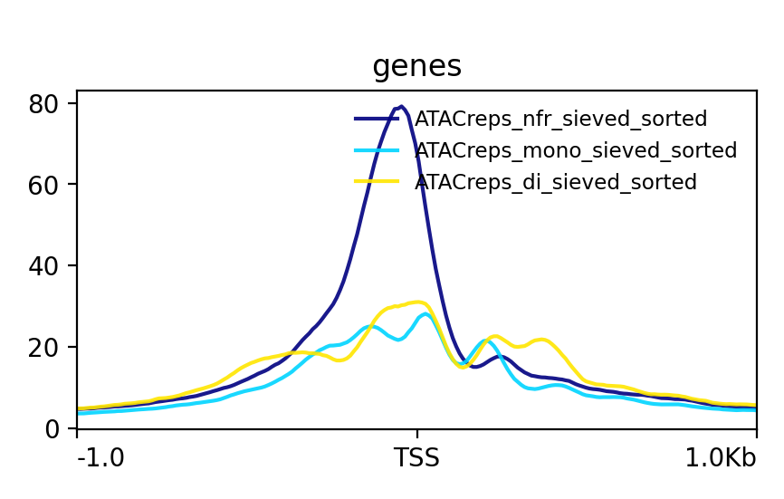

```r
knitr::include_graphics("nucleosome_signal_coverage.png")
```

To assess the amount of signal present around gene regions’ transcription start sites, Deeptools was used to generate a signal coverage plot. Alignment bams were first split by fragment lengths to divide signal coverage into three categories: nucleosome free regions (NFR), mononucleosome bound fragments (mono), and dinucleosome bound fragments (di). Deeptools was used to combine signal coverage from each replicate together, and then to compute a matrix comparing signal coverage for the three categories using hg38 gene regions. The plot shows that NFRs, representing free DNA regions found near gene promoters, have much higher signal compare to mono-/di-nucleosome bound DNA fragments. This information could be used in conjunction with other types of sequencing experiments to analyze patterns of gene expression and gene regulation.

### 4 & 5. Number of reproducible peaks

**Table 2** Table of peak counts

[output not shown]

Peak calling was performed using MACS3 on each replicate, and then bedtools intersect was used to produce a list of reproducible peaks (Replicate 3x4). Additionally, Replicate 3x4 was filtered to exclude known blacklisted regions. Ultimately, there were roughly ~32K reproducible peaks, and this bed file can be found in `results/bedtools/ATACpeaks_noBlacklist.bed`.

### 6. Motif analysis on reproducible peaks

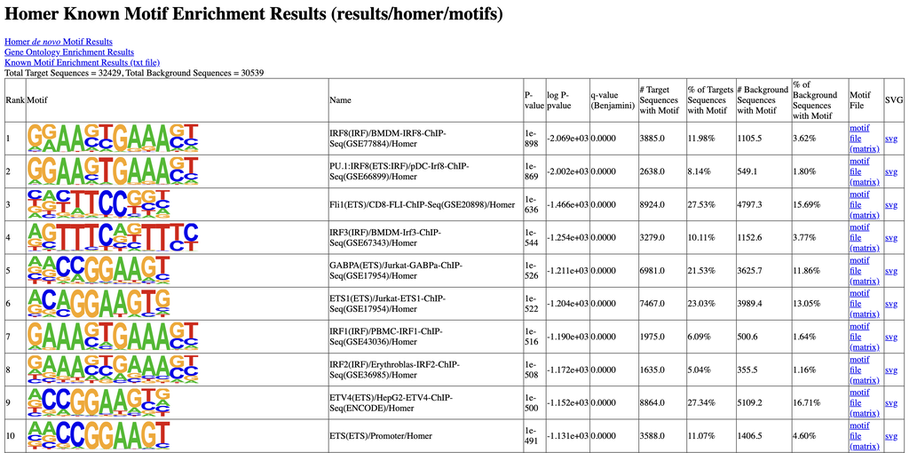

```r
knitr::include_graphics("homer_known_results.png")
```

Homer’s `findMotifsGenome.pl` identifies motifs found in the reproducible peak’s sequences and reports them in the table shown above. In our reproducible peaks, we see an enrichment of Interferon regulatory factor (IRF) family of genes and transcription factors.

### 7. Gene Enrichment Analysis

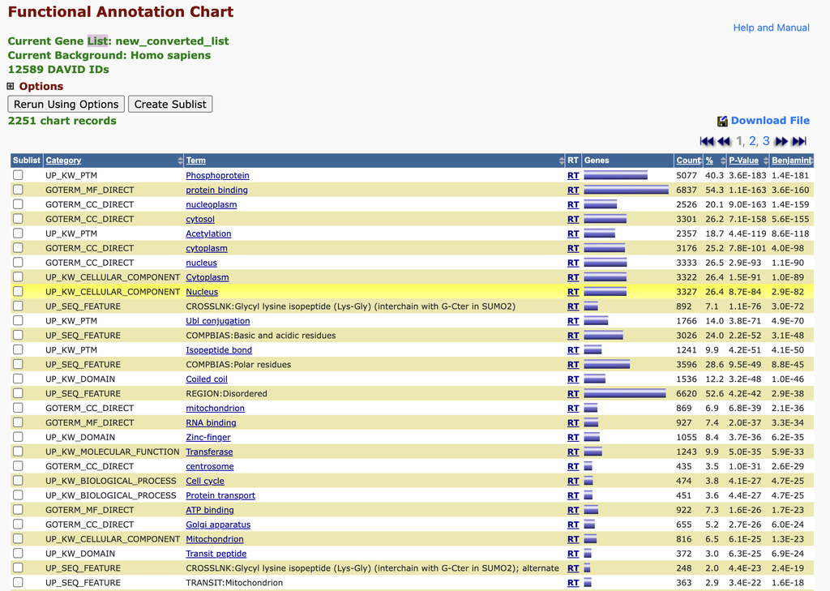

```r
knitr::include_graphics("david_results.png")
```

We manually extracted a list of unique gene names using awk and the annotated peaks file. This list was uploaded and submitted to the DAVID Functional Annotation website to identify cellular functions that have been enriched in the sample. It is hard to discern any clear patterns of enrichment through DAVID. Many of these functions are involved in cellular maintenence and growth.

### 8. Proportion of accessible chromatin regions

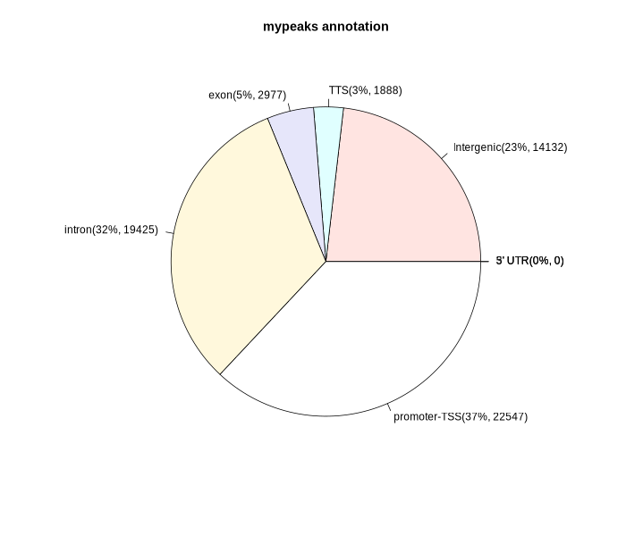

```r
knitr::include_graphics("regions_pie_chart.png")
```

To get an idea of the proportion of different genomic region types being nucleosome free, we generate a pie chart using the annotated peaks file. Expectedly, a large portion of nucleosome free regions tend to be promoters and transcription start sites (~40%). However, introns and intergenic regions make up a large portion of the resulting distribution as well, 32% and 23% respectively. Both of these types of regions may play roles in long-distance regulation of expression.